# CASE METHOD 1

Sania Niwa Ningrum_M0725030

2026-05-26

Pada tahap awal dilakukan proses pemanggilan beberapa *library* yang dibutuhkan untuk mendukung pengolahan data, visualisasi, serta koneksi database pada bahasa pemrograman **R**. Library **DBI** digunakan untuk membangun koneksi antara R dengan database *MySQL Sakila* sehingga data dapat diakses dan diambil menggunakan query SQL. Selanjutnya, library **ggplot2** digunakan untuk membuat visualisasi data seperti boxplot, scatter plot, dan bar chart agar pola data lebih mudah dipahami secara visual.

Selain itu, library **dplyr** digunakan untuk membantu proses manipulasi dan transformasi data seperti filtering, grouping, summarizing, dan pengolahan tabel secara lebih efisien dan terstruktur. Library **scales** digunakan untuk mempercantik tampilan visualisasi, khususnya dalam format angka pada sumbu grafik, seperti mengubah angka menjadi format mata uang (*dollar*) maupun format numerik lain agar lebih mudah dibaca.

Pemanggilan library dilakukan di awal proses analisis agar seluruh fungsi yang diperlukan dapat digunakan pada tahap pengambilan data, pengolahan data, analisis statistik, hingga visualisasi hasil analisis.

```r
library(DBI)
library(ggplot2)
library(dplyr)
library(scales)
```

Tahap selanjutnya adalah melakukan koneksi antara bahasa pemrograman **R** dengan database **Sakila** menggunakan fungsi `dbConnect()` dari package **DBI** dan **odbc**. Koneksi ini bertujuan agar data yang tersimpan pada database MySQL dapat diakses secara langsung melalui R untuk keperluan analisis dan visualisasi data.

Hasil dari proses koneksi tersebut disimpan ke dalam objek `con` yang nantinya digunakan sebagai penghubung utama dalam menjalankan query SQL, mengambil data dari database, serta melakukan proses analisis data lebih lanjut di lingkungan R.

```r
con <- DBI::dbConnect(odbc::odbc(),
                      Driver    = "MySQL ODBC 8.0 ANSI Driver",
                      Server    = "127.0.0.1",
                      Database  = "sakila",
                      UID       = "root",
                      PWD       = "Sukoharjo-0098",
                      Port      = 3306)
```

Setelah koneksi database berhasil dilakukan, tahap berikutnya adalah proses pengambilan data (*data retrieval*) dari database **Sakila** menggunakan query SQL. Pada tahap ini, data diambil sesuai dengan kebutuhan analisis yang akan dilakukan. Query SQL digunakan untuk memilih variabel tertentu, melakukan pengelompokan data, menghitung jumlah transaksi, maupun menggabungkan beberapa tabel yang saling berelasi dalam database.

Data yang berhasil diambil dari database kemudian disimpan ke dalam bentuk *data frame* di lingkungan R agar dapat diolah lebih lanjut. Proses ini memungkinkan data dianalisis menggunakan berbagai metode statistik serta divisualisasikan dalam bentuk grafik untuk memperoleh insight yang lebih mudah dipahami.

Pada tahap pengambilan data pertama, dilakukan proses ekstraksi dan transformasi data untuk mengetahui jumlah transaksi rental berdasarkan waktu dan tipe hari. Query SQL digunakan untuk mengambil data dari tabel `rental` dengan memanfaatkan fungsi `DATE()` untuk mengekstrak tanggal dari `rental_date`, serta struktur `CASE WHEN` untuk mengelompokkan hari menjadi dua kategori, yaitu *Weekday* dan *Weekend* berdasarkan nama hari.

Data yang diambil digunakan untuk menganalisis apakah terdapat perbedaan rata-rata jumlah penyewaan film harian (`total_rental`) antara dua kelompok hari, yaitu *Weekday* dan *Weekend*.

Selanjutnya, data dikelompokkan menggunakan `GROUP BY` berdasarkan tanggal dan tipe hari, kemudian dihitung jumlah transaksi rental menggunakan fungsi `COUNT(rental_id)` sehingga menghasilkan variabel `total_rental`.

$$\text{total\_rental} = \sum \text{rental\_id}$$

```r
query_1 = "SELECT
    DATE(rental_date) AS tanggal,
    CASE
        WHEN DAYNAME(rental_date) IN ( 'Saturday', 'Sunday') THEN 'Weekend'
        ELSE 'Weekday'
    END AS tipe_hari,
    COUNT(rental_id) AS total_rental
FROM rental
GROUP BY DATE(rental_date), tipe_hari;"
data_1 = dbGetQuery(con, query_1)
data_1$total_rental <- as.numeric(data_1$total_rental)
data_1
```

```
##       tanggal tipe_hari total_rental
## 1  2005-05-24   Weekday            8
## 2  2005-05-25   Weekday          137
## 3  2005-05-26   Weekday          174
## 4  2005-05-27   Weekday          166
## 5  2005-05-28   Weekend          196
## 6  2005-05-29   Weekend          154
## 7  2005-05-30   Weekday          158
## 8  2005-05-31   Weekday          163
## 9  2005-06-14   Weekday           16
## 10 2005-06-15   Weekday          348
## 11 2005-06-16   Weekday          324
## 12 2005-06-17   Weekday          325
## 13 2005-06-18   Weekend          344
## 14 2005-06-19   Weekend          348
```

[output cut: 27 more lines]

Pada tahap analisis data pertama, dilakukan pengujian statistik menggunakan metode *Welch Two Sample t-test* melalui fungsi `t.test()` pada bahasa pemrograman **R**. Pengujian ini bertujuan untuk mengetahui apakah terdapat perbedaan rata-rata jumlah penyewaan film harian (`total_rental`) antara dua kelompok hari, yaitu *Weekday* dan *Weekend*.

Hasil pengujian kemudian disimpan ke dalam objek `ttest` agar dapat digunakan kembali untuk proses interpretasi maupun pelaporan hasil analisis. Selanjutnya, fungsi `print(ttest)` digunakan untuk menampilkan output hasil uji statistik yang meliputi nilai statistik uji *t*, derajat kebebasan (*degrees of freedom*), nilai *p-value*, interval kepercayaan (*confidence interval*), serta rata-rata masing-masing kelompok data yang dibandingkan.

```r
ttest <- t.test(total_rental ~ tipe_hari, data = data_1)
print(ttest)
```

```
##
##  Welch Two Sample t-test
##
## data:  total_rental by tipe_hari
## t = -1.2807, df = 18.176, p-value = 0.2164
## alternative hypothesis: true difference in means between group Weekday and group Weekend is not equal to 0
## 95 percent confidence interval:
##  -250.57405   60.69663
## sample estimates:
## mean in group Weekday mean in group Weekend
##              368.1613              463.1000
```

Berdasarkan hasil pengujian statistik menggunakan *Welch Two Sample t-test*, diperoleh nilai statistik uji sebesar $t = -1.2807$ dengan derajat kebebasan (*degrees of freedom*) sebesar $df = 18.176$ dan nilai *p-value* sebesar $0.2164$. Pengujian ini dilakukan untuk mengetahui apakah terdapat perbedaan rata-rata jumlah penyewaan film harian antara kelompok *Weekday* dan *Weekend*.

Hipotesis yang digunakan dalam pengujian ini adalah:

$$H_0 : \mu_{Weekday} = \mu_{Weekend}$$

$$H_1 : \mu_{Weekday} \ne \mu_{Weekend}$$

Hipotesis nol ($H_0$) menyatakan bahwa tidak terdapat perbedaan rata-rata jumlah rental film antara hari kerja dan akhir pekan, sedangkan hipotesis alternatif ($H_1$) menyatakan bahwa terdapat perbedaan rata-rata di antara kedua kelompok tersebut.

Karena nilai *p-value* lebih besar dibandingkan taraf signifikansi yang digunakan, yaitu $\alpha = 0.05$, maka keputusan yang diambil adalah gagal menolak hipotesis nol ($0.2164 > 0.05$). Hal ini menunjukkan bahwa secara statistik tidak terdapat bukti yang cukup kuat untuk menyatakan adanya perbedaan rata-rata volume penyewaan film antara kelompok *Weekday* dan *Weekend*.

Berdasarkan hasil estimasi rata-rata sampel, diperoleh bahwa rata-rata jumlah rental pada kelompok *Weekday* adalah sebesar $368.1613$ transaksi per hari, sedangkan rata-rata pada kelompok *Weekend* sebesar $463.1000$ transaksi per hari. Secara deskriptif, nilai tersebut menunjukkan bahwa aktivitas penyewaan film pada akhir pekan cenderung lebih tinggi dibandingkan hari kerja dengan selisih rata-rata sekitar:

$$463.1000 - 368.1613 = 94.9387$$

Meskipun demikian, selisih rata-rata tersebut belum dapat dianggap signifikan secara statistik karena masih dipengaruhi oleh variasi data harian yang cukup besar. Hal ini diperkuat oleh interval kepercayaan 95% yang berada pada rentang:

$$-250.57405 \le (\mu_{Weekday} - \mu_{Weekend}) \le 60.69663$$

Karena interval kepercayaan tersebut mencakup angka nol, maka perbedaan rata-rata antara kedua kelompok masih memungkinkan bernilai nol atau bahkan berlawanan arah. Dengan kata lain, belum terdapat bukti statistik yang cukup kuat bahwa jumlah rental film pada akhir pekan benar-benar lebih tinggi secara konsisten dibandingkan hari kerja.

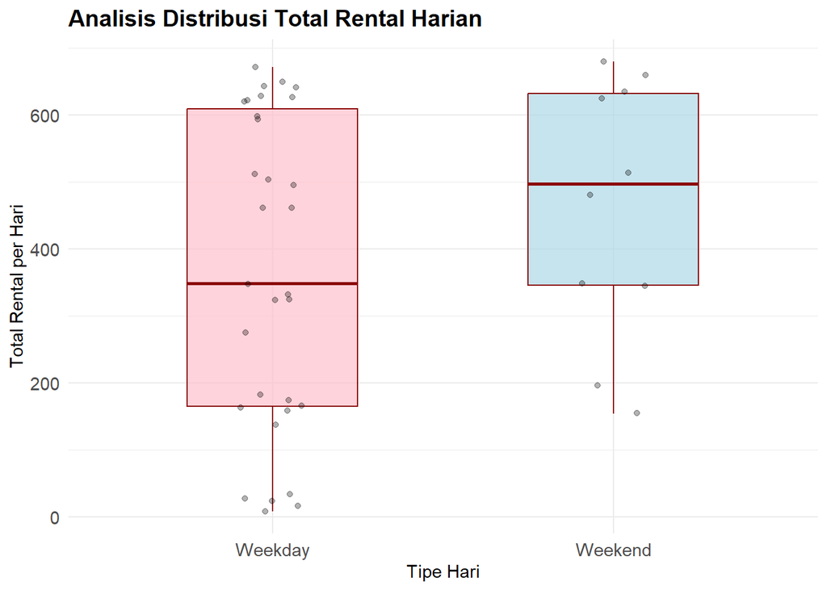

```r
# Membuat Boxplot Perbandingan Jumlah Rental
ggplot(data_1, aes(x = tipe_hari, y = total_rental, fill = tipe_hari)) +
  geom_boxplot(alpha = 0.7, width = 0.5, color = "darkred") +
  # Menambahkan titik data asli agar sebaran data makin kelihatan jelas
  geom_jitter(width = 0.1, alpha = 0.3, color = "black") +
  # Mengatur warna: Weekday (Biru), Weekend (Oranye)
  scale_fill_manual(values = c("Weekday" = "pink", "Weekend" = "lightblue")) +
  labs(
    title = "Analisis Distribusi Total Rental Harian",
    x = "Tipe Hari",
    y = "Total Rental per Hari"
  ) +
  theme_minimal() +
  theme(
    plot.title = element_text(face = "bold", size = 14),
    plot.subtitle = element_text(italic = TRUE, size = 10, color = "black"),
    axis.text = element_text(size = 11),
    legend.position = "none" # Menghilangkan legenda karena label x sudah jelas
  )
```

Berdasarkan boxplot terlihat bahwa distribusi jumlah penyewaan film pada kelompok *Weekend* cenderung lebih tinggi dibandingkan *Weekday*. Hal ini dapat dilihat dari posisi garis median pada kelompok *Weekend* yang berada di sekitar $500$ transaksi per hari, sedangkan median pada kelompok *Weekday* hanya berada di kisaran $350$ transaksi per hari.

Perbedaan median tersebut menunjukkan bahwa secara umum aktivitas penyewaan film pada akhir pekan lebih ramai dibandingkan hari kerja. Kondisi ini dapat dijelaskan karena pelanggan cenderung memiliki waktu luang yang lebih banyak pada akhir pekan sehingga frekuensi penyewaan film meningkat. Selain itu, posisi box pada kelompok *Weekend* juga terlihat lebih tinggi secara keseluruhan dibandingkan *Weekday*, yang mengindikasikan bahwa sebagian besar nilai transaksi akhir pekan berada pada tingkat yang relatif tinggi.

Dari sisi penyebaran data, kelompok *Weekday* memiliki rentang distribusi yang lebih lebar dibandingkan *Weekend*. Hal ini terlihat dari ukuran box (*Interquartile Range/IQR*) dan whisker pada kelompok *Weekday* yang lebih panjang. Secara matematis, IQR dapat dinyatakan sebagai:

$$IQR = Q_3 - Q_1$$

Nilai IQR yang lebih besar menunjukkan bahwa variasi data pada kelompok *Weekday* lebih tinggi sehingga volume rental pada hari kerja cenderung lebih fluktuatif atau tidak stabil. Pada beberapa hari kerja terjadi jumlah rental yang sangat rendah, bahkan mendekati nol transaksi, sementara pada hari lainnya dapat meningkat hingga lebih dari $600$ transaksi per hari.

Di sisi lain, terdapat pula beberapa titik dengan nilai sangat tinggi pada kedua kelompok yang mengindikasikan adanya lonjakan transaksi pada hari-hari tertentu. Namun secara keseluruhan, meskipun kelompok *Weekend* menunjukkan kecenderungan volume rental yang lebih tinggi secara visual, distribusi kedua kelompok masih saling tumpang tindih (*overlap*) dalam jumlah yang cukup besar.

Temuan visual ini sejalan dengan hasil pengujian statistik menggunakan *Welch Two Sample t-test* sebelumnya yang menunjukkan bahwa perbedaan rata-rata antara kelompok *Weekday* dan *Weekend* belum signifikan secara statistik. Dengan demikian, meskipun secara deskriptif akhir pekan memiliki aktivitas rental yang lebih tinggi, peningkatan tersebut belum cukup konsisten untuk membuktikan adanya perbedaan rata-rata yang signifikan secara statistik.

Pada tahap pengambilan data kedua, dilakukan proses ekstraksi data untuk menganalisis kontribusi pendapatan (*revenue*) dari masing-masing negara pada database **Sakila**. Query SQL digunakan untuk menggabungkan beberapa tabel yang saling berelasi, yaitu tabel `customer`, `address`, `city`, `country`, dan `payment`.

Variabel `co.country` digunakan untuk mengambil nama negara pelanggan dan diberi alias `negara`. Selanjutnya, fungsi agregasi:

$$COUNT(DISTINCT\ c.customer\_id)$$

digunakan untuk menghitung jumlah pelanggan unik pada masing-masing negara sehingga diperoleh variabel `total_pelanggan`. Sementara itu, fungsi:

$$SUM(p.amount)$$

digunakan untuk menghitung total pendapatan (*total revenue*) yang diperoleh dari seluruh transaksi pembayaran pelanggan pada tiap negara.

Data kemudian dikelompokkan berdasarkan negara menggunakan perintah:

$$GROUP\ BY\ co.country$$

sehingga setiap negara memiliki ringkasan jumlah pelanggan dan total revenue masing-masing. Setelah itu, hasil query diurutkan berdasarkan nilai `total_revenue` secara menurun (*descending*) menggunakan:

$$ORDER\ BY\ total\_revenue\ DESC$$

Tujuan pengurutan ini adalah untuk mempermudah identifikasi negara dengan kontribusi pendapatan terbesar terhadap perusahaan rental film.

Hasil query kemudian disimpan ke dalam objek `data_2` menggunakan fungsi `dbGetQuery()`. Dataset tersebut selanjutnya digunakan untuk proses visualisasi dan analisis lebih lanjut terkait distribusi revenue antarnegara pada database Sakila.

```r
query_2 = "SELECT
    co.country AS negara,
    COUNT(DISTINCT c.customer_id) AS total_pelanggan,
    SUM(p.amount) AS total_revenue
FROM customer c
JOIN address a ON c.address_id = a.address_id
JOIN city ci ON a.city_id = ci.city_id
JOIN country co ON ci.country_id = co.country_id
JOIN payment p ON c.customer_id = p.customer_id
GROUP BY co.country
ORDER BY total_revenue DESC;"
data_2 = dbGetQuery(con, query_2)
head(data_2)
```

```
##          negara total_pelanggan total_revenue
## 1         India              60       6628.28
## 2         China              53       5798.74
## 3 United States              36       4110.32
## 4         Japan              31       3470.75
## 5        Mexico              30       3307.04
## 6        Brazil              28       3200.52
```

Pada tahap berikutnya, dilakukan proses pengambilan *Top 10* negara dengan kontribusi revenue terbesar dari dataset `data_2`. Proses ini dilakukan menggunakan fungsi `head()` pada bahasa pemrograman **R**, yaitu:

$$top10 \leftarrow head(data\_2,\ 10)$$

Fungsi `head()` digunakan untuk mengambil sejumlah baris pertama dari suatu dataset. Karena sebelumnya data telah diurutkan berdasarkan `total_revenue` secara menurun (*descending*), maka sepuluh baris pertama pada `data_2` merepresentasikan sepuluh negara dengan total pendapatan tertinggi pada database Sakila.

```r
top10<- head(data_2, 10)
top10
```

```
##                negara total_pelanggan total_revenue
## 1               India              60       6628.28
## 2               China              53       5798.74
## 3       United States              36       4110.32
## 4               Japan              31       3470.75
## 5              Mexico              30       3307.04
## 6              Brazil              28       3200.52
## 7  Russian Federation              28       3045.87
## 8         Philippines              20       2381.32
## 9              Turkey              15       1662.12
## 10            Nigeria              13       1511.48
```

Pada tahap visualisasi data kedua, digunakan *bar chart* menggunakan package **ggplot2** untuk menampilkan *Top 10* negara dengan kontribusi revenue terbesar. Grafik dibuat menggunakan fungsi `geom_bar()` dengan tinggi batang merepresentasikan total pendapatan (*total revenue*) masing-masing negara.

Warna batang menggunakan gradasi dari *lightblue* hingga *darkblue* untuk memperjelas perbedaan besar revenue antarnegara. Selain itu, fungsi `label_dollar()` digunakan agar sumbu revenue ditampilkan dalam format mata uang dollar sehingga lebih mudah dibaca dan diinterpretasikan.

Visualisasi ini bertujuan untuk mempermudah identifikasi negara-negara yang memberikan kontribusi pendapatan terbesar terhadap perusahaan rental film pada database Sakila.

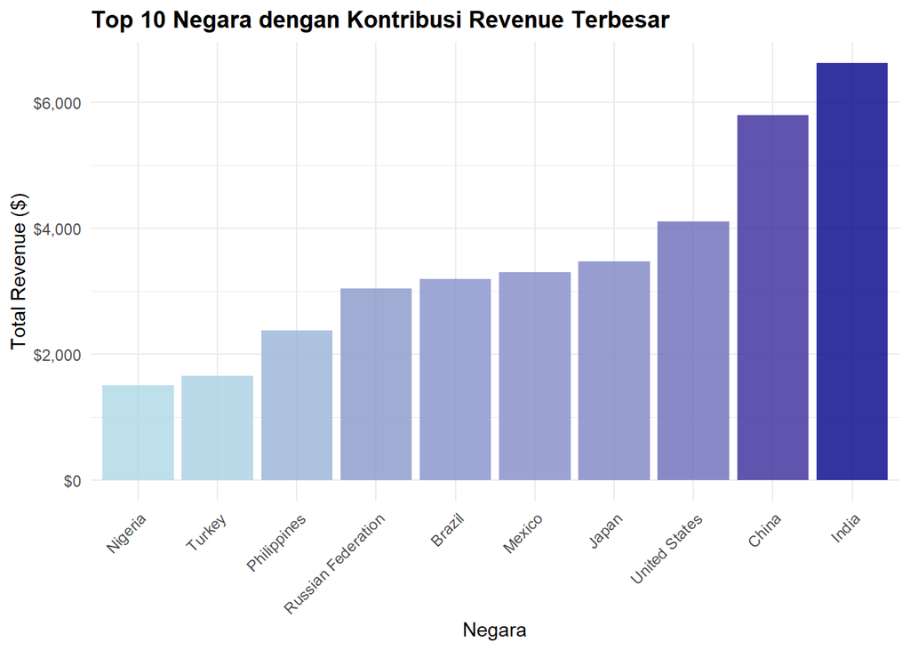

```r
ggplot(top10, aes(x = reorder(negara, total_revenue), y = total_revenue, fill = total_revenue)) +
  geom_bar(stat = "identity", alpha = 0.8) +
  scale_fill_gradient(low = "lightblue", high = "darkblue") +
  scale_y_continuous(labels = label_dollar())+
  labs(
    title = "Top 10 Negara dengan Kontribusi Revenue Terbesar",
    x = "Negara",
    y = "Total Revenue ($)"
  ) +
  theme_minimal() +
theme(
    axis.text.x = element_text(angle = 45, hjust = 1),
    legend.position = "none",
    plot.title = element_text(face = "bold")
  )
```

Pada tahap pengambilan data ketiga, dilakukan proses analisis hubungan antara frekuensi penyewaan film pelanggan dan total denda keterlambatan yang dibayarkan. Query SQL digunakan untuk mengambil data dari beberapa tabel yang saling berelasi, yaitu tabel `payment`, `rental`, `inventory`, dan `film` menggunakan perintah *JOIN*.

```r
query_3 = "SELECT
    p.customer_id,
    COUNT(p.rental_id) AS total_sewa,
    SUM(p.amount) - SUM(f.rental_rate) AS total_denda
FROM payment p
JOIN rental r ON p.rental_id = r.rental_id
JOIN inventory i ON r.inventory_id = i.inventory_id
JOIN film f ON i.film_id = f.film_id
GROUP BY p.customer_id;"
data_3 = dbGetQuery(con, query_3)
head (data_3)
```

```
##   customer_id total_sewa total_denda
## 1         431         23          29
## 2         518         26          30
## 3         279         31          39
## 4         411         26          19
## 5         170         26          36
## 6         161         30          29
```

Pada tahap analisis data ketiga, dilakukan uji korelasi menggunakan fungsi `cor.test()` untuk mengetahui hubungan antara jumlah penyewaan film pelanggan (`total_sewa`) dengan total denda keterlambatan yang dibayarkan (`total_denda`).

Sebelum pengujian dilakukan, kedua variabel terlebih dahulu dikonversi ke dalam tipe data numerik menggunakan fungsi `as.numeric()` agar dapat diproses dalam analisis statistik. Selanjutnya, fungsi:

$$cor.test(total\_sewa,\ total\_denda)$$

digunakan untuk mengukur kekuatan dan arah hubungan antara kedua variabel tersebut. Hasil pengujian kemudian disimpan ke dalam objek `uji_korelasi` dan ditampilkan menggunakan `print()`.

Melalui analisis ini, dapat diketahui apakah pelanggan yang lebih sering menyewa film cenderung memiliki total denda keterlambatan yang lebih tinggi atau tidak.

```r
data_3$total_sewa <- as.numeric(data_3$total_sewa)
data_3$total_denda <- as.numeric(data_3$total_denda)

uji_korelasi <- cor.test(data_3$total_sewa, data_3$total_denda)
print(uji_korelasi)
```

```
##
##  Pearson's product-moment correlation
##
## data:  data_3$total_sewa and data_3$total_denda
## t = 19.306, df = 597, p-value < 2.2e-16
## alternative hypothesis: true correlation is not equal to 0
## 95 percent confidence interval:
##  0.5680619 0.6669467
## sample estimates:
##       cor
## 0.6199599
```

Berdasarkan hasil uji korelasi menggunakan *Pearson’s Product-Moment Correlation*, diperoleh nilai koefisien korelasi sebesar $r = 0.6199599$ dengan nilai statistik uji $t = 19.306$ dan derajat kebebasan $df = 597$. Nilai *p-value* yang diperoleh adalah $p\text{-value} < 2.2 \times 10^{-16}$, yang berarti jauh lebih kecil dibandingkan taraf signifikansi $\alpha = 0.05$.

Karena nilai *p-value* sangat kecil $(p < 0.05)$, maka keputusan yang diambil adalah menolak hipotesis nol $(H_0)$. Hal ini menunjukkan bahwa terdapat hubungan yang signifikan secara statistik antara jumlah penyewaan film pelanggan (`total_sewa`) dan total denda keterlambatan (`total_denda`).

Nilai koefisien korelasi positif sebesar $0.6199$ menunjukkan bahwa hubungan antara kedua variabel bersifat positif dengan kekuatan korelasi berada pada kategori sedang hingga kuat. Artinya, semakin sering pelanggan melakukan penyewaan film, maka cenderung semakin besar pula total denda keterlambatan yang dibayarkan pelanggan tersebut.

Selain itu, interval kepercayaan 95% berada pada rentang:

$$0.5680619 \le \rho \le 0.6669467$$

Karena seluruh rentang interval berada di atas nol, hal ini semakin memperkuat bahwa hubungan positif antara frekuensi penyewaan dan total denda benar-benar konsisten pada populasi pelanggan.

Pada tahap visualisasi data ketiga, digunakan *scatter plot* untuk melihat hubungan antara frekuensi penyewaan film pelanggan (`total_sewa`) dengan total denda keterlambatan (`total_denda`). Visualisasi dibuat menggunakan fungsi `ggplot()` dengan `geom_point()` untuk menampilkan sebaran data setiap pelanggan.

Selain itu, ditambahkan garis regresi linear menggunakan fungsi `geom_smooth(method = “lm”)` untuk memperlihatkan arah hubungan antarvariabel. Secara matematis, model regresi linear sederhana dapat dinyatakan sebagai:

$$y = \beta_0 + \beta_1 x$$

dengan:

- $x$ = total frekuensi penyewaan film
- $y$ = total denda keterlambatan
- $\beta_0$ = intercept
- $\beta_1$ = koefisien arah hubungan

Visualisasi ini bertujuan untuk memperjelas pola hubungan antara aktivitas penyewaan pelanggan dengan kecenderungan meningkatnya total denda keterlambatan yang dibayarkan.

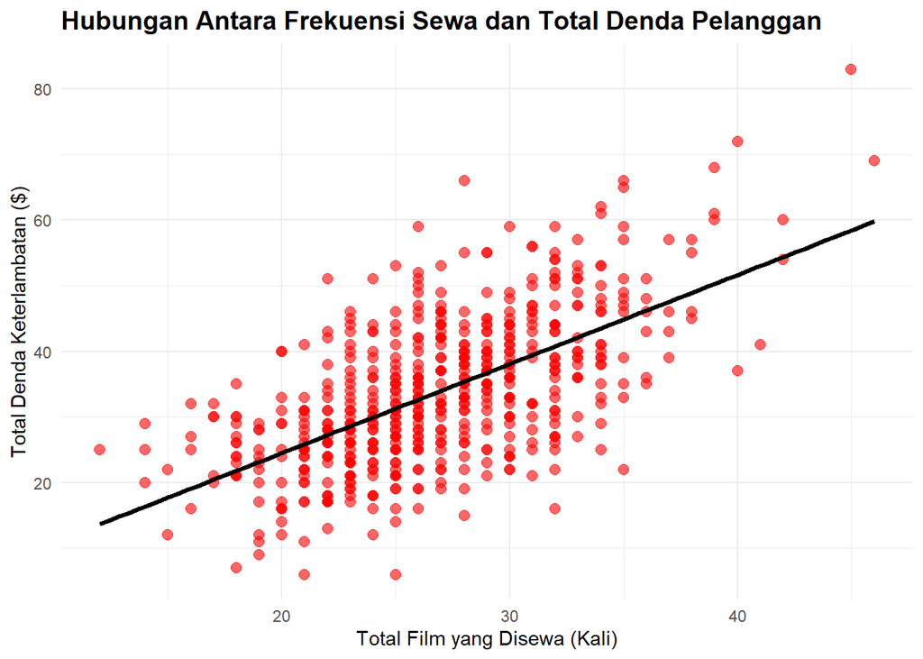

```r
ggplot(data_3, aes(x = total_sewa, y = total_denda)) +
  geom_point(color = "red", alpha = 0.6, size = 2.5) +
  geom_smooth(method = "lm", color = "black", se = FALSE, size = 1.2) +
  labs(
    title = "Hubungan Antara Frekuensi Sewa dan Total Denda Pelanggan",
    x = "Total Film yang Disewa (Kali)",
    y = "Total Denda Keterlambatan ($)"
  ) +
  theme_minimal() +
  theme(plot.title = element_text(face = "bold", size = 14))
```

Berdasarkan visualisasi scatter plot “Hubungan Antara Frekuensi Sewa dan Total Denda Pelanggan”, terlihat adanya hubungan positif antara jumlah film yang disewa pelanggan dengan total denda keterlambatan yang dibayarkan. Hal ini ditunjukkan oleh pola persebaran titik yang cenderung bergerak dari kiri bawah menuju kanan atas serta diperkuat oleh garis regresi linear yang memiliki arah kemiringan positif.

Semakin tinggi frekuensi penyewaan film pelanggan, maka semakin besar pula kecenderungan total denda keterlambatan yang dimiliki pelanggan tersebut. Sebagian besar pelanggan berada pada rentang 20–35 kali penyewaan dengan total denda sekitar $20 hingga $50.

Selain itu, terlihat beberapa titik ekstrem (outlier) pada bagian kanan atas grafik yang menunjukkan adanya pelanggan dengan frekuensi sewa sangat tinggi disertai total denda yang besar, bahkan melebihi $80. Kondisi ini menunjukkan bahwa pelanggan aktif memiliki potensi keterlambatan pengembalian yang lebih tinggi dibandingkan pelanggan lain.

Walaupun terdapat variasi data yang cukup besar, pola hubungan positif masih terlihat cukup jelas. Hal ini sejalan dengan hasil uji korelasi Pearson sebelumnya yang menghasilkan nilai koefisien korelasi sebesar:

$$r = 0.6199$$

Nilai tersebut menunjukkan bahwa hubungan antara frekuensi penyewaan dan total denda berada pada kategori sedang hingga kuat dengan arah hubungan positif.